# Eksamenstest 4

Steen Bender 3. December 2024

```python
# Import stuff for code
import numpy as np
import pandas as pd
from IPython.display import Markdown as md
import matplotlib.pyplot as plt
import matplotlib as mpl
from usefull_functions import *

mpl.rcParams["font.size"] = 22
```

### Opgave 1 - Ligevægte

Mælkesyre (C3H6O3) er en svag monovalent syre der ved 25°C har  
syrestyrkekonstanten KA = 1,45·10-4 M,  
vands ionprodukt er KV = 1,0·10-14 M2.

#### a) Beregn pKA for mælkesyre og pKB for mæleksyres korresponderende base.

$$pK_a = -log(KA)$$$$pK_b = 14 - pK_a$$$$pK_a = -log(1,45·10^{-4}) = 3,84$$$$pK_b = 14 - 3,84 = 10,16$$

#### b) Beregn [H+], [HA] samt [A-] i en 0,100 M opløsning af mælkesyre.

$$HA \rightleftharpoons H^+ + A^-$$

| HA | H+ | A- |
| --- | --- | --- |
| 0,100 | 0 | 0 |
| -x | +x | +x |
| 0,100-x | x | x |

$$ K_a = \frac{[H^+][A^-]}{[HA]} = 1,45·10^{-4}$$$$ 1,45·10^{-4} = \frac{x^2}{0,100-x}$$$$ x = 0,004$$$$ [H^+] = [A^-] = 0,004 M, [HA] = 0,096 M$$

#### c) Beregn fordelingen mellem mælkesyre og dennes korresponderende base i blod (pH = 7,40).

$$pH = pK_a + log(\frac{[A^-]}{[HA]})$$$$7,40 = 3,84 + log(\frac{[A^-]}{[HA]})$$$$3,56 = log(\frac{[A^-]}{[HA]})$$$$10^{3,56} = \frac{[A^-]}{[HA]} = 3642$$

Korreponderende base er 3642 gange mere end mælkesyre, derfor er der 'kun' dette i blodet. ___

#### Pufferkapaciteten af blod er faktisk ret lav, nemlig kun 38,5 mM med pKA = 7,4. Et menneske indeholder 5 L blod. Sukker har en molvægt på 342,30 g/mol, og forbrændes anaerobt ved denne reaktion:

$$C_{12}H_{22}O_{11} + H_2O = 2C_6H_{12}O_6 = 4C_3H_6O_3$$

#### d) Hvor meget mælkesyre dannes det ved anerob forbrænding af 10 g sukker

$$\frac{10 g}{342,30 g/mol} = 0,029 mol$$$$0,029 mol * 4 = 0,117 mol$$

#### e) Hvor meget ændres pH i blodet ved anaerob forbrænding af 10 g sukker

$$n(Buffer\:i\:blod) = 5 L * 38,5 mM = 0,193 mol$$$$7,40 = 7,4 + log(\frac{0,193}{0,193})$$$$\downarrow$$$$pH = 7,40 + log(\frac{0,193-0,117}{0,193+0,117})$$$$pH = 7,40 + log(\frac{0,076}{0,310})$$$$ pH = 7,40 + log(0,245) = 7,40 - 0,61 = 6,79$$

Calciumlaktat Ca(C3H5O3)·5H2O er letopløseligt og bruges til berigelse af soyamælk, havremælk m.m.

#### f) Beregn pH af en 0,050 M opløsning af calciumlaktat i vand.

$$ Ca^{2+} + 2C_3H_5O_3^{-} + 2H_2O = 2OH^- + 2C_3H_6O_3 + Ca^{2+}$$

| Ca2+ | C3H5O3- | OH- | C3H6O3 | Ca2+ |
| --- | --- | --- | --- | --- |
| 0,050 | 0,100 | 1e-7 | 0 | 0,050 |
| - | -x | +x | +x | - |

0,050 | 0,100-x | 1e-7+x | x | 0,050 |

$$K_a = 10^{-3,86} = 0.000138038$$$$ K_a * K_b = K_v = 1,0·10^{-14}$$

Fra pKa = 3,86 set på wikipedia

$$ K_b = \frac{K_v}{K_a} = \frac{1,0·10^{-14}}{1,38·10^{-4}} = 7,25·10^{-11}$$$$7,25·10^{-11} = \frac{x \cdot (10^{-7} + x)}{0,100-x}$$$$x = 2,64·10^{-6}$$$$ pH = 14 - pOH = 14 + log(10^{-7} + 2,64·10^{-6}) = 14 - 5,56 = 8,42$$

### Opgave 2 - pH

I skal fremstille en buffer med en bufferstyrke på 0,333 M, som kan holde fysiologisk på pH = 7,5, og med isotonisk salt. I har følgende reagenser til rådighed: 1M NaOH, NaCl, MES, CHES, HEPES, PBS, og TRIS. Alle bufferne er på syreformen.

#### a) Hvilke to reagenser kan I ikke bruge, svaret begrundes alene med pKA

pKa:

MES: 6,15  
CHES: 9,30  
HEPES: 3,0 & 7,5  
BPS: ~7,4  
TRIS: 8,07

MES og CHES kan ikke bruges, da de har en pKA på 6,15 og 9,30, hvilket er udenfor det ønskede interval. ___

#### b) For alle de svage syrer plottes et Bjerrum diagram. Den ønskede pH angives på plottet. Der må bruges én graf i besvarelsen.

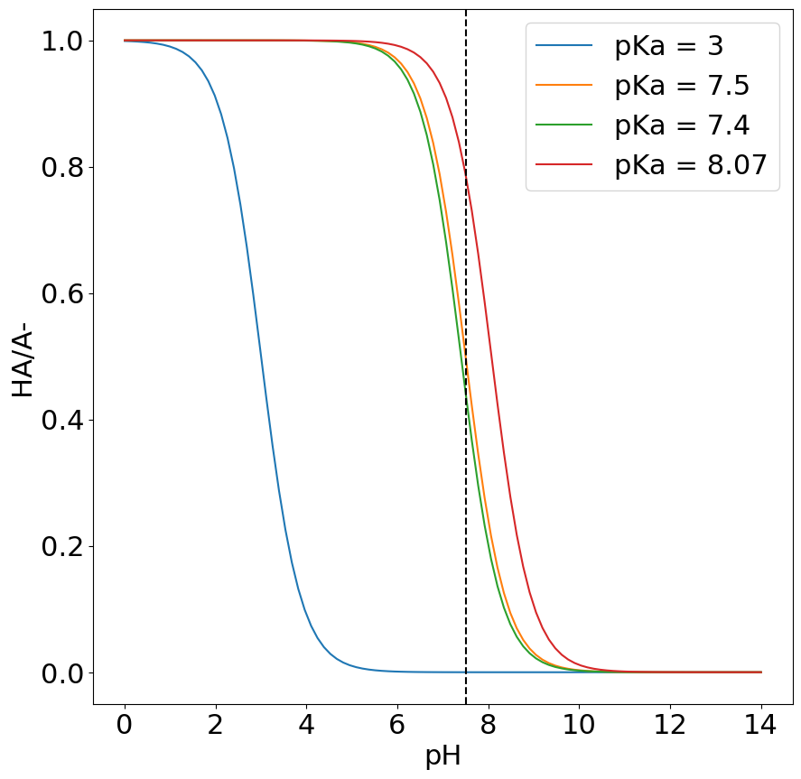

```python
pkas = [3, 7.5, 7.4, 8.07]
pHs = np.linspace(0, 14, 1000)
fig, ax = plt.subplots(figsize=(10, 10))
_ = plot_bjerum_diagram(pkas, ax=ax)
ax.axvline(7.5, color="black", linestyle="--")
```

#### c) Forslå en opskrift på bufferen.

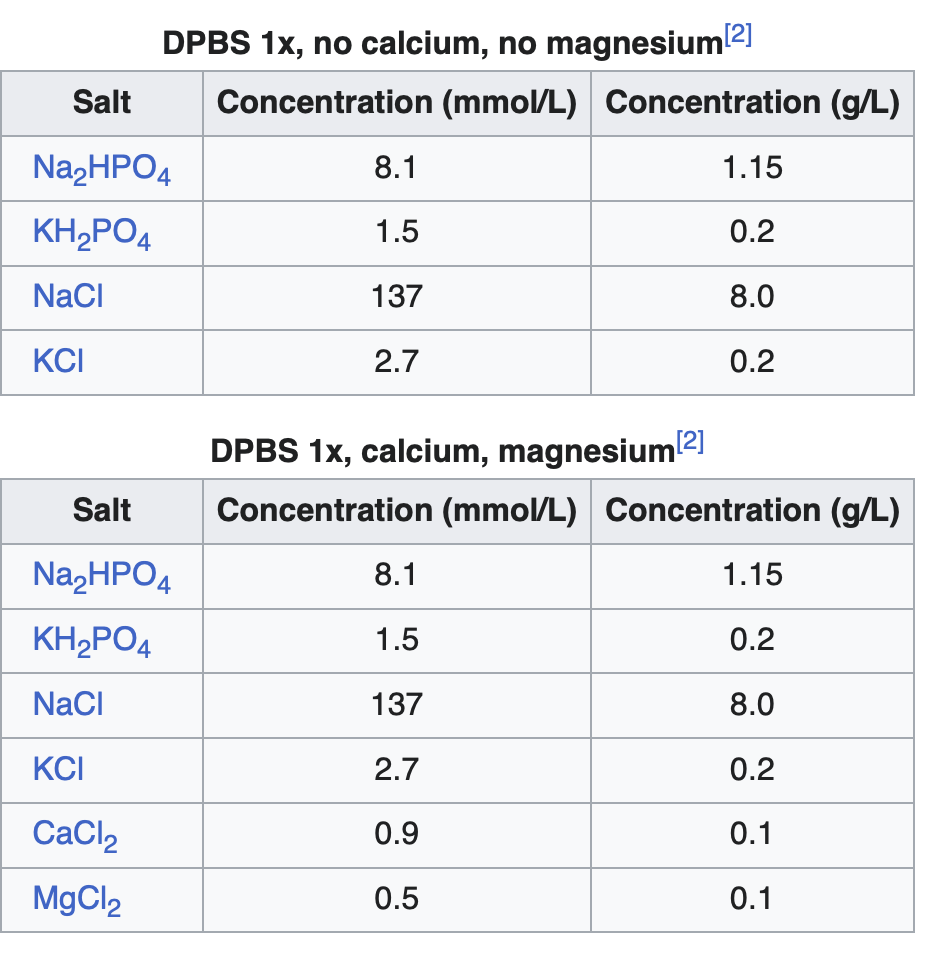

___ PBS buffer står for ‘phosphate buffered saline’ er isotonisk, men koncentrationen af fosfat er kun 10 mM og derfor for lav.

Vi bruger HEPES i stedet, pKa = 7,48

Isotonisk saltvand Google --> 0,9% NaCl = 0,154 M NaCl

(HEPES) Google --> 238,30 g/mol

pKa = pH ⇔ [A] = [HA], så vi skal bruge 0,666 M HEPES og 0,333 (+ 0,666) M NaOH Vi laver 1 L

### Opgave 3 - Termodynamik og kinetik

En metode til at lave polyethylen (tænk fryseposer) er at starte en kædereaktion med brint radikaler

$$C_2H_4(g) + H(g) = C_2H_5\cdot$$

| k [cm³/(molec·s)] | 2.00e13 | 2.98e13 | 4.01e13 | 6.31e13 | 9.43e13 | 11.34e13 | 14.52e13 |
| --- | --- | --- | --- | --- | --- | --- | --- |
| T [K] | 198 | 216 | 234 | 258 | 283 | 298 | 320 |

#### a) Bestem reaktionsordenen og opskriv et godt bud på hastighedsudtrykket. Der må bruges én graf i besvarelsen.

$$k[\frac{cm^3}{n \cdot s}]$$

Så 'k' er VOLUME over MOL gange SEKUND

eller:

$$ k[M^-1 \cdot s^-1]$$$$Rate = k \cdot [C_2H_4] \cdot [H]$$$$ Enheden \: for \: k = \frac{Enheden\: for\: Rate}{Enheden \: for \: [Konsentration]^{reaktions orden}}$$

Enheden af Rate er givet ved $M/s$ so for at dette opholdes

Så for at Raten kan overholdes til at være $M/s$ skal reaktionsordenen være 2, da $[C_2H_4]$ og $[H]$ begge er i mol.

Hvilket resultere i en hastighedskonstant på $k = [M^-1 \cdot s^-1]$

#### b) Lav et Arrhenius plot of bestem Ea og A.

$$ k = A \cdot e^{-\frac{E_a}{R \cdot T}}$$$$ ln(k) = ln(A) - \frac{E_a}{R} \cdot \frac{1}{T}$$$$ y = a + bx$$

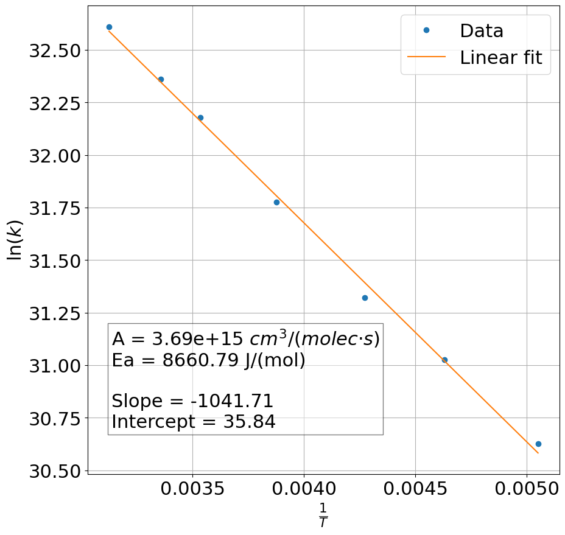

```python
T = np.array([198, 216, 234, 258, 283, 298, 320])  # Temperature in Kelvin
k = np.array(
    [2.00e13, 2.98e13, 4.01e13, 6.31e13, 9.43e13, 11.34e13, 14.52e13]
)  # Rate constant in cm³/(molec·s)

inv_T = 1 / T
ln_k = np.log(k)

slope, intercept = np.polyfit(inv_T, ln_k, 1)
R = 8.314  # J/(mol·K)
Ea = -slope * R
A = np.exp(intercept)

text = f"A = {A:.2e} $cm^3/(molec·s)$\nEa = {Ea:.2f} J/(mol)\n\nSlope = {slope:.2f}\nIntercept = {intercept:.2f}"


fig, ax = plt.subplots(figsize=(10, 10))
ax.plot(inv_T, ln_k, "o", label="Data")
ax.text(
    0.05,
    0.1,
    text,
    transform=ax.transAxes,
    fontsize=22,
    bbox=dict(facecolor="white", alpha=0.5),
)
ax.plot(inv_T, slope * inv_T + intercept, label="Linear fit")
ax.set_xlabel(r"$\frac{1}{T}$")
ax.set_ylabel(r"$\ln(k)$")
ax.grid()
ax.legend()
```

#### c) Kommenter på størrelsen af Ea.

8 kJ/mol er en lav aktivereingsenergi, hvilket ofte ses for radikalreaktioner ___

Reaktionen mellem solventet og 0,0465 M tert-butylklorid blev monitoreret ved at titrere 5 mL af reaktionsblandingen med 0,025 M NaOH:

$$(H_3C)_3CCl(aq) + H_2O(l) = (H_3C)_3COH(aq) + HCl(aq)$$

| t [h] | 0.5 | 1.0 | 1.5 | 2.0 | 3.0 | 4.0 | 5.0 | 6.5 | 8.0 | 10.0 |
| --- | --- | --- | --- | --- | --- | --- | --- | --- | --- | --- |
| V NaOH [mL] | 0.65 | 1.28 | 1.85 | 2.35 | 3.32 | 4.18 | 4.88 | 5.70 | 6.40 | 7.22 |

#### d) Omregn dataserien til t [s] mod [(H3C)3CCl] [M].

5 ml = 0,005 L reaktions blanding $c(^tBuCl)$ = 0,0465 M

$$ n(HCl) = n(NaOH) = V(NaOH) \cdot [NaOH] = V(NaOH) \cdot 0,025 M$$

```python
tid = np.array([0.5, 1.0, 1.5, 2.0, 3.0, 4.0, 5.0, 6.5, 8.0, 10.0])  # Tid i timer
V_NaOH = np.array(
    [0.65, 1.28, 1.85, 2.35, 3.32, 4.18, 4.88, 5.70, 6.40, 7.22]
)  # NaOH-volumen i mL
c_NaOH = 0.025  # Koncentration af NaOH i M
V_blanding = 5  # Volumen af reaktionsblandingen i mL
c_start_tBuCl = 0.0465  # Oprindelig koncentration af tBuCl i M

# Beregning af n(NaOH) i mmol
n_NaOH = V_NaOH * c_NaOH  # mL * M -> mmol

# Beregning af [tBuCl] (M) over tid
c_tBuCl = c_start_tBuCl - n_NaOH / V_blanding

data = pd.DataFrame(
    {
        "Tid (h)": tid,
        "Tid (s)": tid * 3600,
        "V_NaOH (mL)": V_NaOH,
        "n_NaOH (mmol)": n_NaOH,
        "[tBuCl] (M)": c_tBuCl,
    }
)

data
```

|  | Tid (h) | Tid (s) | V_NaOH (mL) | n_NaOH (mmol) | [tBuCl] (M) |
| --- | --- | --- | --- | --- | --- |
| 0 | 0.5 | 1800.0 | 0.65 | 0.01625 | 0.04325 |
| 1 | 1.0 | 3600.0 | 1.28 | 0.03200 | 0.04010 |
| 2 | 1.5 | 5400.0 | 1.85 | 0.04625 | 0.03725 |
| 3 | 2.0 | 7200.0 | 2.35 | 0.05875 | 0.03475 |
| 4 | 3.0 | 10800.0 | 3.32 | 0.08300 | 0.02990 |
| 5 | 4.0 | 14400.0 | 4.18 | 0.10450 | 0.02560 |
| 6 | 5.0 | 18000.0 | 4.88 | 0.12200 | 0.02210 |
| 7 | 6.5 | 23400.0 | 5.70 | 0.14250 | 0.01800 |
| 8 | 8.0 | 28800.0 | 6.40 | 0.16000 | 0.01450 |
| 9 | 10.0 | 36000.0 | 7.22 | 0.18050 | 0.01040 |

#### e) Bestem reaktionsorden og hastighedskonstant. Der må bruges tre grafer i besvarelsen

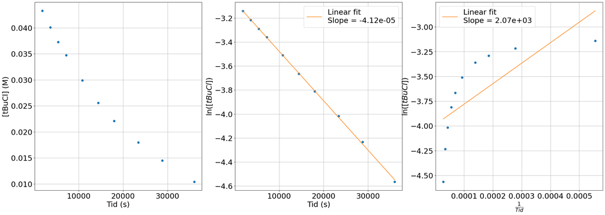

```python
fig, ax = plt.subplots(1, 3, figsize=(30, 10))
y = data["[tBuCl] (M)"]
x = data["Tid (s)"]
ax[0].plot(x, y, "o")
ax[0].set_xlabel("Tid (s)")
ax[0].set_ylabel("[tBuCl] (M)")
ax[0].grid()

y = np.log(data["[tBuCl] (M)"])
x = data["Tid (s)"]
ax[1].plot(x, y, "o")
ax[1].set_xlabel("Tid (s)")
ax[1].set_ylabel(r"$\ln([tBuCl])$")
ax[1].grid()

slope, intercept = np.polyfit(x, y, 1)
ax[1].plot(x, slope * x + intercept, label="Linear fit\nSlope = {:.2e}".format(slope))
ax[1].legend()

y = 1 / data["Tid (s)"]
x = np.log(data["[tBuCl] (M)"])
ax[2].plot(y, x, "o")
ax[2].set_xlabel(r"$\frac{1}{Tid}$")
ax[2].set_ylabel(r"$\ln([tBuCl])$")
ax[2].grid()

slope, intercept = np.polyfit(y, x, 1)
ax[2].plot(y, slope * y + intercept, label="Linear fit\nSlope = {:.2e}".format(slope))
ax[2].legend()

plt.show()
```

### Opgave 4 - Elektrokemi

Kobber(II)bromat reagerer med iodid under sure betingelser.

#### a) Opskriv ligevægten der indstiller sig når Kobber(II)bromat opløses i 12 M saltsyre.

$$Cu(BrO_3)_2(s) = Cu^{2+} + 2BrO_3^-$$

Kobber(II) bromat kan indeholde vand, og for at bestemme, hvor mange krystalvand der er i stoffet, reageres stoffet med iodid. Husk at iod reagerer med overskud af iodid og danner triiodid.

#### b) Opskriv og afstem ligevægten, hvor kobber(II) reagerer med iodid og danner kobber(I)iodid

$$ 2Cu^{2+}(aq) + 5I^-(aq) = 2CuI(s) + I_2(s) + I^-(aq) = 2CuI(s) + I_3^-(aq)$$

#### c)Opskriv og afstem ligevægten, hvor bromat reagerer med iodid og danner bromid

$$ 6H^+ + BrO_3^- + 9I^- = Br^-(aq) + 3I_2(s) + 3I^-(aq) + 3H_2O = Br^-(aq) + 3I_3^-(aq) + 3H_2O$$

#### d) Hvor mange mol triiodid dannes der når 1 mol kobber(II)bromat reagerer

$$ 1 \: mol \: Cu(BrO_3)_2 = 1 mol \: Cu^{2+} + 2 \: mol \: BrO_3^-$$$$Cu^{2+} \rightarrow 1/2 I_3^-$$$$BrO_3^- \rightarrow 3 I_3^-$$$$ 0,5 + 2 \cdot 3 = 6,5 \: mol \: I_3^-$$

Mængden af triiodid kan bestemmes med titrering med thiosulfat. 84,55 mg kobber(II)bromat med X krystalvand i 8 mL 12 M HCl med 1 g KI, hvorved der straks dannes et hvidt fast stof. Denne opløsning titreres med 24,84 mL 0,1035 M natriumthiosulfat opløsning.

#### e) Opskriv og afstem ligevægten mellem triiodid og thiosulfat, beregn Ecelle og ΔGꝋ for reaktionen

$$ 2S_2O_3^{2-} + I_3^- = 3I^- + S_4O_6^{2-}$$$$ 2S_2O_3^{2-} \rightarrow S_4O_6^{2-} + 2e^-$$$$ I_3^- + 2e^- = 3I^-$$$$ E_{cell} = E_{I_3^-/I^-} - E_{S_2O_3^{2-}/S_4O_6^{2-}} = 0,15 - 0,08 = 0,07 V$$$$ \Delta G^ꝋ = -n \cdot F \cdot E_{cell} = -2 \cdot 96485 \cdot 0,07 = -13539 J = -13,5 kJ$$$$ k = e^{\frac{-\Delta G^ꝋ}{RT}} = e^{\frac{13539}{8,314 \cdot 298}} = 236,19$$

#### f) Beregn stofmængden af opløst kobber(II)bromat

$$n(thiosulfat) = V(thiosulfat) \cdot c(thiosulfat) = 0,02484 \cdot 0,1035 = 0,00257 mol$$$$n(triiodid) = 1/2 \cdot n(thiosulfat) = 0,00129 mol$$$$n(Cu(BrO_3)_2) = n(triiodid)/6,5 = 0,000198 mol$$

#### g) Udregn molmassen og tallet X.

$$M = \frac{m}{n} = \frac{0,08455}{0,000198} = 427,98 g/mol$$$$M(Cu(BrO_3)_2) = 319,45 g/mol \rightarrow google$$$$ X = \frac{M - M(Cu(BrO_3)_2)}{M(H_2O)} = \frac{427,98 - 319,45}{18,015} = 6,03$$$$ Cu(BrO_3)_2 \cdot 6H_2O$$